# 第9回 顔画像を、少ない数で持つ

主成分分析を行列の計算で書く

# 導入

## 前回は平均で縮めた

① 場面●○○○○

- 2,000本の遺伝子を、一緒に動くまとまりに分けた
- まとまりごとの平均で、10本ほどの点数に縮めた
- 平均は、いちばん単純な縮め方

## 今日は情報を残して縮める

① 場面●●○○○

- たくさんの数でできたデータを、少ない数に縮める
- できるだけ情報を失わない縮め方を学ぶ
- 題材は、顔の画像

## 場面：顔認証の開発チーム

① 場面●●●○○

- あなたは、入館ゲートの顔認証を作る開発チームの一員
- 登録した人の顔の画像と、カメラに写った顔を比べて、誰かを当てる

## 1枚は4,096個の数

① 場面●●●●○

- 顔の画像1枚は、4,096個の数
- そのまま持つと、記憶も、比べる計算も重い
- ただし、少なくしすぎて見分けられなくなっては困る

## 決めたいこと

① 場面●●●●●

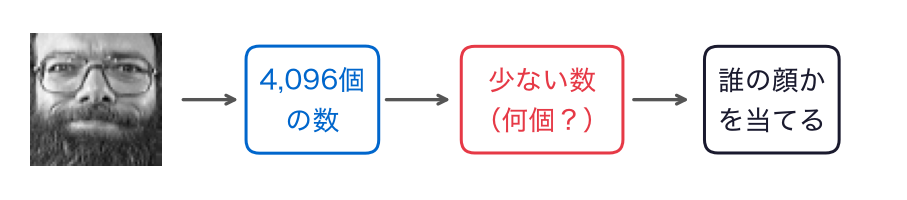

- 1枚を何個の数で持てば、誰の顔かを見分けられるか

## 手元のデータ

② 手元のデータ●○

- AT&T研究所（英国ケンブリッジ）が1992〜1994年に撮った顔の画像（Olivettiの顔画像。scikit-learnが配布）
- 40人について、1人10枚。表情や眼鏡、顔の向きを少しずつ変えてある

## 1行が1枚

② 手元のデータ●●

- 1枚は縦64 × 横64＝4,096画素の白黒の画像
- 値は画素の明るさ。0が黒、1が白
- 先頭の列`person`が人の番号（0〜39）

## 最後に出す答え

③ 今日の問い●○

- 1枚を何個の数で持てばよいか
- その数で持ったとき、誰の顔かを当てる力（正解率）がどれだけ残るか

## 今日の問い

③ 今日の問い●●

顔の画像1枚（4,096画素）を、見分ける力を保ったまま、何個の数で持てばよいか？

## もう1つのねらい：行列の積

④ もう1つのねらい●○

- 表を行列として見て、縮める・戻すを行列の積で書けるようになる

## @と.Tで書く

④ もう1つのねらい●●

- 縮める：得点＝ずれ`@`向きの転置
- 戻す：得点`@`向き＋平均

## この問いにどう近づくか

⑤ 今日の問い●○

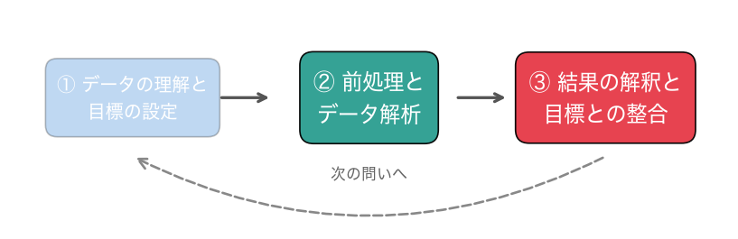

縮める方法（データ解析）を中心に、何個で持つか（結果の解釈）まで進みます。

## 今日の道筋

⑤ 今日の問い●●

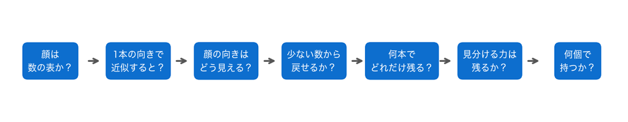

- 7つの小さな問いに答えていく

# 0. 準備

## まずは道具とデータ

- 第9回のノートを開き、上から順にセルを実行する
- 顔の画像の表を読み込み、訓練とテストに分ける

## お手本：道具を呼び出す

0節 ① 道具とデータ●○○○○

```python
import numpy as np
import pandas as pd
import matplotlib.pyplot as plt
from sklearn.decomposition import PCA
from sklearn.neighbors import KNeighborsClassifier
from sklearn.pipeline import make_pipeline
from sklearn.model_selection import train_test_split, StratifiedKFold
from sklearn.model_selection import cross_val_score
```

- 主成分分析の`PCA`、いちばん近いものを探す`KNeighborsClassifier`が加わる

## 練習用の道具：show_faces

0節 ① 道具とデータ●●○○○

```python
def show_faces(faces, titles):
    n = len(faces)
    plt.figure(figsize=(2.2 * n, 2.6))
    for k in range(n):
        plt.subplot(1, n, k + 1)
        plt.imshow(faces[k].reshape(64, 64), cmap='gray')
        plt.title(titles[k], fontsize=12)
        plt.axis('off')
    plt.show()
```

- 顔を何枚か横に並べて描く道具。中身は読み飛ばしてよい

## 役割・入力・出力だけ読む

0節 ① 道具とデータ●●●○○

- 役割：4,096個の数の並びを、顔の画像として横に並べる
- 入力：顔の並びのリスト`faces`と、見出しのリスト`titles`
- 出力：顔を並べた図

## お手本：表を読み込む

0節 ① 道具とデータ●●●●○

```python
# データはこのリポジトリから読み込む
DATA_DIR = ('https://raw.githubusercontent.com/k0heiun0/'
            'applied_exercise_preview/main/shared/data')
df = pd.read_csv(f'{DATA_DIR}/olivetti_faces.csv.gz', index_col=0)
print(df.shape)
df.iloc[:3, :5]
```

- 大きいので圧縮してある（`.csv.gz`。第8回と同じ）

## 400行 × 4,097列

0節 ① 道具とデータ●●●●●

```
(400, 4097)
       person     px0     px1     px2     px3
image
0           0  0.3099  0.3678  0.4174  0.4421
1           0  0.4545  0.4711  0.5124  0.5579
2           0  0.3182  0.4008  0.4917  0.5289
```

- 先頭の列`person`が人の番号。`px0`〜`px4095`が画素の明るさ

## お手本：訓練とテストに分ける

0節 ② 訓練とテスト●○

```python
person = df['person'].values
X = df.drop(columns='person').values
X_tr, X_te, p_tr, p_te = train_test_split(
    X, person, test_size=0.25, random_state=0, stratify=person)
print(X_tr.shape, X_te.shape)
```

- `.values`でnumpyの配列にする。今日は表を行列として計算する
- `stratify=person`：どの人も同じ割合で分ける（第6回）

## 訓練300枚、テスト100枚

0節 ② 訓練とテスト●●

```
(300, 4096) (100, 4096)
```

- どちらも、1枚が4,096個の数
- テストの100枚は、最後に1回だけ使う

## やってみよう：0節

0節 ③ 確かめる●

- 0節のセルを上から実行し、表の大きさを確かめる

動画の人は、ここで一時停止。

# 1. 顔は数の表か？

## 1行は本当に顔か

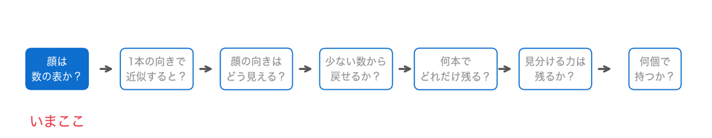

- 表が読めた。1行の4,096個の数が、本当に顔なのかを確かめる

## おさらい：reshape

1節 ① 行と画像●○○○○

```python
a = np.arange(6)                  # 0, 1, 2, 3, 4, 5
print(a.reshape(2, 3))
```

```
[[0 1 2]
 [3 4 5]]
```

- 並びの形を変える。左から順に、1行目、2行目と詰める

## 画像も1行ずつ並べたもの

1節 ① 行と画像●●○○○

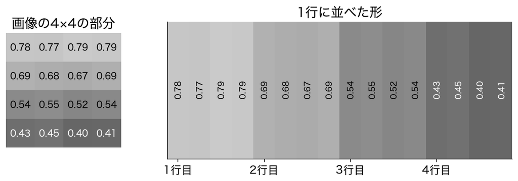

- 左上から右へ、1行ずつ並べると4,096個になる

## 戻すにはreshape(64, 64)

1節 ① 行と画像●●●○○

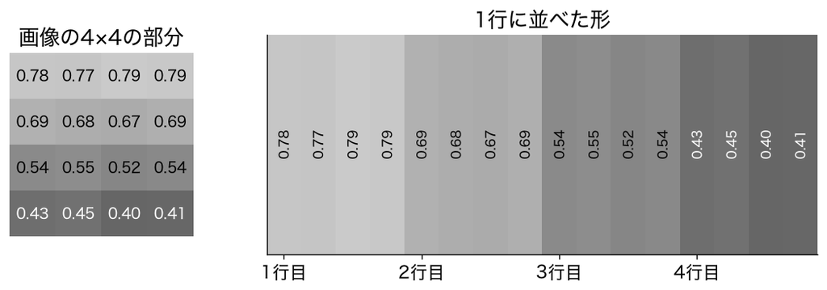

- 4,096個を`reshape(64, 64)`にすれば、画像の形に戻る

## お手本：1行を顔に戻す

1節 ① 行と画像●●●●○

```python
img = X_tr[0].reshape(64, 64)       # 4,096個を64行×64列に
plt.imshow(img, cmap='gray')
plt.title(f'人の番号 {p_tr[0]}')
plt.axis('off')
plt.show()
```

- `plt.imshow`：数の表を画像として描く
- `cmap='gray'`：小さい数を黒、大きい数を白にする

## 4,096個の数が顔になった

1節 ① 行と画像●●●●●

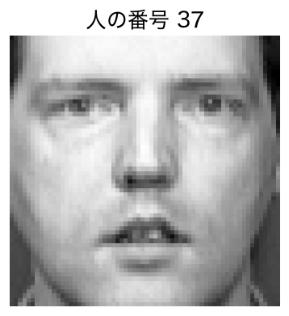

- この人の番号は37

## 変えてみる：同じ人を並べる

1節 ② 同じ人●○○

```python
same = X_tr[p_tr == 37]
print(len(same), '枚')
show_faces(same[:4], ['1枚目', '2枚目', '3枚目', '4枚目'])
```

- `X_tr[p_tr == 37]`：番号が37の行だけを残す
- 並べて描くのは、0節の`show_faces`

## 同じ人でも少しずつ違う

1節 ② 同じ人●●○

```
8 枚
```

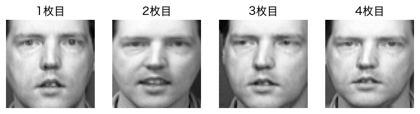

- 番号37の人は、訓練に8枚。表情や顔の向きが少しずつ違う

## 違いがあっても見分けたい

1節 ② 同じ人●●●

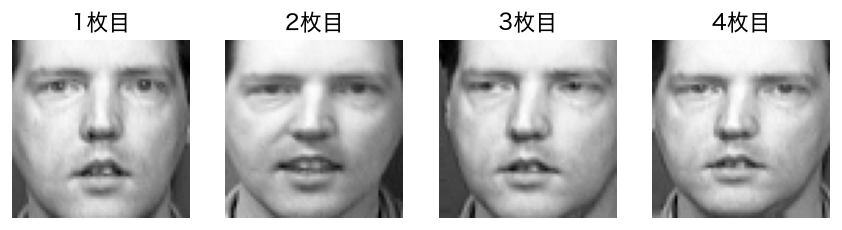

- この違いがあっても、誰の顔かを見分けたい

## お手本：平均の顔

1節 ③ 平均の顔●○○

```python
mean_face = X_tr.mean(axis=0)       # 画素ごとの平均（4,096個）
print(mean_face.shape)
plt.imshow(mean_face.reshape(64, 64), cmap='gray')
plt.axis('off')
plt.show()
```

- `mean(axis=0)`：縦の方向に（300枚をまたいで）平均する

## axis=0は縦の方向

1節 ③ 平均の顔●●○

- pandasの`mean()`は、列ごとの平均が決まりだった
- numpyでは、`axis=0`で縦の方向を指定する
- 画素ごとに300枚の平均を出すので、4,096個になる

## ぼんやりした顔

1節 ③ 平均の顔●●●

```
(4096,)
```

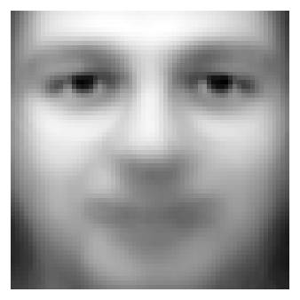

- 300枚の顔に共通する形

## 記号で書く：平均の顔

1節 ④ 平均からのずれ●○○○○○

- $i$枚目の画像の4,096個の並びを$\mathbf{x}_i$、平均の顔を$\bar{\mathbf{x}}$と書く

$$\bar{\mathbf{x}} = \frac{1}{n}\sum_{i=1}^{n} \mathbf{x}_i$$

- $n$は枚数（訓練なら300）

## 顔＝平均＋ずれ

1節 ④ 平均からのずれ●●○○○○

- 平均からのずれは$\mathbf{x}_i - \bar{\mathbf{x}}$
- どの顔も「平均の顔＋その顔のずれ」
- 顔ごとの違いは、ずれのほうにある

## TODO①：ずれを描く

1節 ④ 平均からのずれ●●●○○○

```python
# TODO: 5枚目・平均の顔・ずれ を並べて描く
# ヒント: show_faces([X_tr[4], mean_face, X_tr[4] - mean_face],
#                    ['写真', '平均', 'ずれ'])
...
```

- 訓練の5枚目`X_tr[4]`と、平均の顔とのずれ

## やってみよう：1節とTODO①

1節 ④ 平均からのずれ●●●●○○

- 1節のお手本を実行する
- TODO①で、5枚目の顔と平均の顔とのずれを描く

動画の人は、ここで一時停止。

## 答え合わせ：TODO①

1節 ④ 平均からのずれ●●●●●○

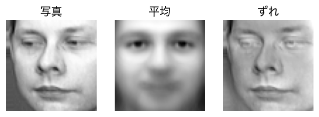

```python
show_faces([X_tr[4], mean_face, X_tr[4] - mean_face],
           ['写真', '平均', 'ずれ'])
```

## ずれが、その顔らしさ

1節 ④ 平均からのずれ●●●●●●

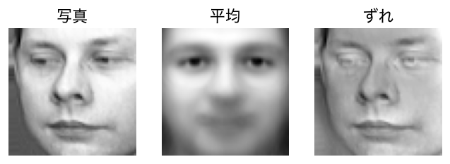

- 平均より明るい画素が白く、暗い画素が黒い
- このずれを、少ない数で表す方法を考える

# 2. 1本の向きで近似するには？

## まず2画素で考える

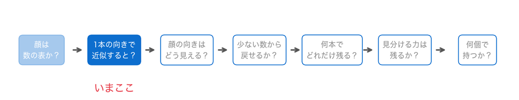

- ずれは4,096個の数。4,096次元の図は描けない
- まず2画素だけで考える。2画素なら散布図に描ける

## お手本：2画素を取り出す

2節 ① 2画素●○○○○

```python
two = X_tr[:, [1300, 1324]]        # 20行目の20列目と44列目
print(two.shape)
print(np.corrcoef(two[:, 0], two[:, 1])[0, 1].round(3))
```

- 20行目の20列目は、$20 \times 64 + 20 = 1300$番目
- `np.corrcoef`は相関係数の表。`[0, 1]`で2つの間の値

## 左右の目のあたり

2節 ① 2画素●●○○○

```
(300, 2)
0.817
```

- 300枚 × 2画素。相関係数は0.817

## 左が明るいと右も明るい

2節 ① 2画素●●●○○

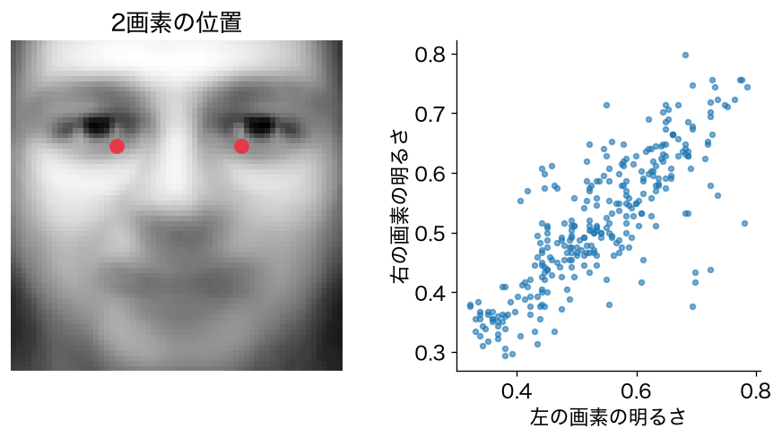

- 右上がりの細長い形に集まっている

## 変えてみる：ずれにする

2節 ① 2画素●●●●○

```python
xc = two - two.mean(axis=0)        # 平均からのずれ
print(xc.mean(axis=0).round(3))
```

```
[0. 0.]
```

- 1節と同じく、列ごとの平均を引く。ずれの平均は0

## 中心が原点に来た

2節 ① 2画素●●●●●

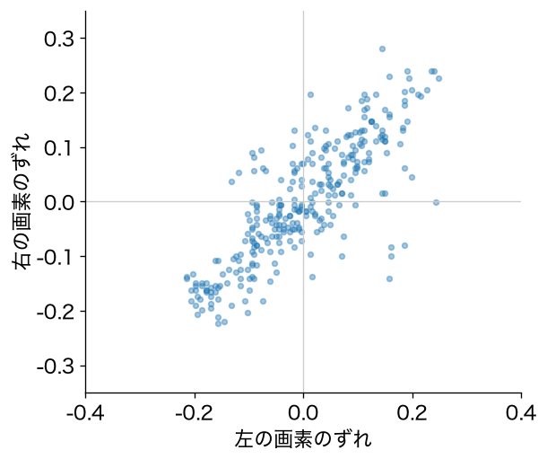

## 1本の直線で近似する

2節 ② 向きと得点●○○○○

- 原点を通る直線を引き、各点を直線上の点で近似する

## 垂直に下ろす：射影

2節 ② 向きと得点●●○○○

- 点から直線に垂直に下ろした足が、近似の点
- 垂直に下ろすことを、射影と呼ぶ

## 記号で書く：向き

2節 ② 向きと得点●●●○○

- 直線の向きを、長さ1の矢印$\mathbf{w} = (\cos\theta, \sin\theta)$で表す
- $\theta$は、横軸から測った角度
- $\mathbf{x}_i$は、ここでは2画素のずれ

## 記号で書く：得点と誤差

2節 ② 向きと得点●●●●○

- 得点：$t_i = \mathbf{x}_i \mathbf{w}^\top$（向きに沿って進んだ所）
- 近似：$t_i \mathbf{w}$（直線上の点）
- 誤差：$\sum_{i} \| \mathbf{x}_i - t_i \mathbf{w} \|^2$（距離の二乗を全員で足す）

## 誤差が最小の向きを探す

2節 ② 向きと得点●●●●●

## おさらい：@と.T

2節 ③ 行列の積●○

```python
A = np.array([[1, 2]])             # 1行2列
print(A.T)                           # 2行1列
print(np.array([[3, 4]]) @ A.T)      # (1行2列) @ (2行1列) → 1行1列
```

```
[[1]
 [2]]
[[11]]
```

## 掛けて足すと1つの数

2節 ③ 行列の積●●

- `@`は行列の積、`.T`は転置（第2回）
- $3 \times 1 + 4 \times 2 = 11$
- 1行2列と2行1列の積は、2つの数を掛けて足した1つの数

## お手本：30度で近似する

2節 ④ 30度の向き●○○○

```python
theta = np.deg2rad(30)
W = np.array([[np.cos(theta), np.sin(theta)]])   # 向き：1行2列
t = xc @ W.T                       # 得点：300行1列
approx = t @ W                     # 近似：300行2列
print(t.shape, approx.shape)
print(round(((xc - approx) ** 2).sum(), 3))      # 誤差
```

## 1行ずつ読む

2節 ④ 30度の向き●●○○

- `np.deg2rad(30)`：30度を、計算用の角度の単位（ラジアン）に
- `np.cos`・`np.sin`：余弦と正弦。向き`W`は1行2列
- `xc @ W.T`：300枚それぞれ、2つの数を掛けて足す＝得点

## 記号とコードの対応

2節 ④ 30度の向き●●●○

| 記号 | コード | 形 |
| --- | --- | --- |
| $t_i = \mathbf{x}_i \mathbf{w}^\top$ | `t = xc @ W.T` | 300行1列 |
| $t_i \mathbf{w}$ | `approx = t @ W` | 300行2列 |
| 誤差 | `((xc - approx) ** 2).sum()` | 1つの数 |

## 30度の誤差は1.075

2節 ④ 30度の向き●●●●

```
(300, 1) (300, 2)
1.075
```

- この誤差が、もっと小さくなる向きはあるか

## 変えてみる：向きを回す

2節 ⑤ 向きを回す●○○

```python
errs = []
for deg in range(180):
    theta = np.deg2rad(deg)
    W = np.array([[np.cos(theta), np.sin(theta)]])
    t = xc @ W.T
    errs.append(((xc - t @ W) ** 2).sum())
best = np.argmin(errs)
print(best, '度', round(errs[best], 3))
```

- お手本と同じ計算を、角度を1度ずつ変えて180回
- `np.argmin`：いちばん小さい値の位置（第7回）。位置がそのまま角度

## 45度で最小

2節 ⑤ 向きを回す●●○

```
45 度 0.666
```

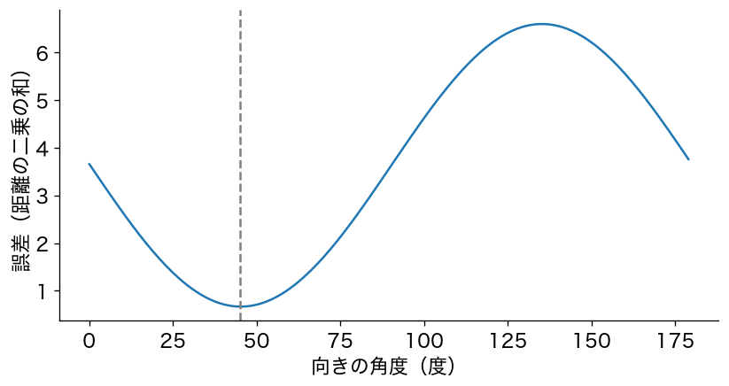

## 細長い方向に合わせた

2節 ⑤ 向きを回す●●●

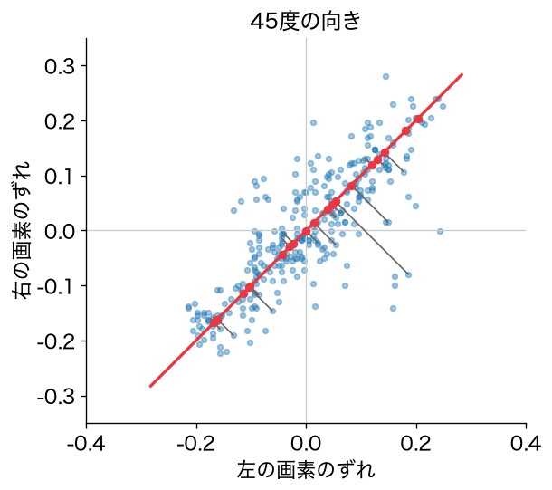

- 誤差0.666。点の集まりの細長い方向に、直線が合った

## 名前：第1主成分

2節 ⑥ 主成分●○○

- 誤差がいちばん小さくなる向きを、第1主成分と呼ぶ
- 第1主成分に射影した位置$t_i$を、主成分得点と呼ぶ
- ずれを少ない本数の向きで近似する方法が、主成分分析（PCA）

## お手本：PCAで向きを求める

2節 ⑥ 主成分●●○

```python
pca2 = PCA(n_components=1).fit(two)
print(pca2.components_.round(3))
theta = np.deg2rad(best)
print(np.round([np.cos(theta), np.sin(theta)], 3))
```

- `n_components=1`：向きを1本だけ求める。平均は`PCA`が中で引く
- 求めた向きは`components_`に入る

## PCAの向きと、ほぼ同じ

2節 ⑥ 主成分●●●

```
[[0.704 0.71 ]]
[0.707 0.707]
```

- 小さな違いは、1度ずつしか回していないため
- 符号が両方逆になっても、矢印が逆向きなだけで同じ直線

## 散らばりとの関係は？

2節 ⑦ 散らばり●○○○○

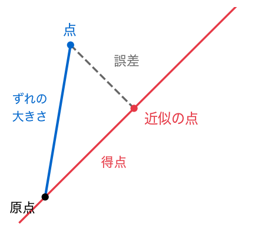

- 点・近似の点・原点は、直角三角形を作る

## 三平方の定理

2節 ⑦ 散らばり●●○○○

$$\|\mathbf{x}_i\|^2 = t_i^2 + \|\mathbf{x}_i - t_i \mathbf{w}\|^2$$

- 左辺：ずれの大きさ。向きによらず決まっている
- 右辺：得点の二乗＋誤差

## 誤差が最小なら散らばりが最大

2節 ⑦ 散らばり●●●○○

- 全員で足すと、左辺の合計は一定
- 誤差が最小の向きは、得点の二乗和が最大の向き
- 得点の平均は0なので、得点の散らばり（分散）が最大の向き

## お手本：足し算を確かめる

2節 ⑦ 散らばり●●●●○

```python
theta = np.deg2rad(best)
W = np.array([[np.cos(theta), np.sin(theta)]])
t = xc @ W.T
print(round((xc ** 2).sum(), 3))             # ずれの大きさの合計
print(round((t ** 2).sum(), 3))              # 得点の二乗和
print(round(((xc - t @ W) ** 2).sum(), 3))   # 誤差
```

## 7.265＝6.599＋0.666

2節 ⑦ 散らばり●●●●●

```
7.265
6.599
0.666
```

- 第1主成分は、誤差が最小の向きであり、得点がいちばん散らばる向き

## TODO②：直交する向き

2節 ⑧ 直交する向き●○○○○

```python
# TODO: 135度の向きで、得点・近似・誤差を計算し、誤差を表示する
# ヒント: お手本の theta = np.deg2rad(30) を 135 にする
...
```

- 第1主成分（45度）に直交する向きは、45＋90＝135度

## やってみよう：2節とTODO②

2節 ⑧ 直交する向き●●○○○

- 2節のお手本を実行し、誤差が最小の角度を確かめる
- TODO②で、135度の向きの誤差を出す

動画の人は、ここで一時停止。

## 答え合わせ：TODO②

2節 ⑧ 直交する向き●●●○○

```python
theta = np.deg2rad(135)
W = np.array([[np.cos(theta), np.sin(theta)]])
t = xc @ W.T
approx = t @ W
print(round(((xc - approx) ** 2).sum(), 3))
```

```
6.599
```

## 135度で誤差が最大

2節 ⑧ 直交する向き●●●●○

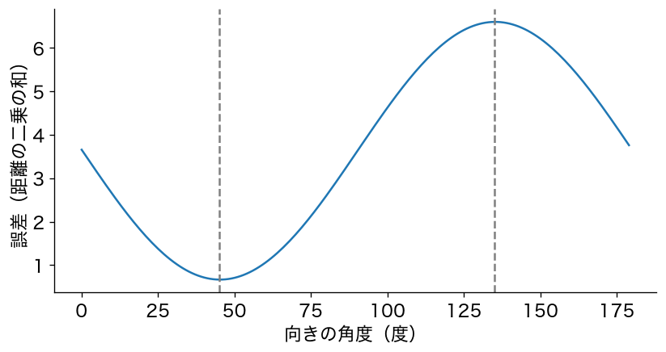

- 誤差6.599は、180通りの中でいちばん大きい

## 残りの散らばりがこの向きに

2節 ⑧ 直交する向き●●●●●

- 135度の向きの得点の二乗和は、0.666しかない
- 第1主成分で残しきれなかった散らばりが、この向きに残る
- この向きが第2主成分。2画素なら、2本で誤差0

# 3. 顔の向きはどう見えるか？

## 4,096画素ではPCAに任せる

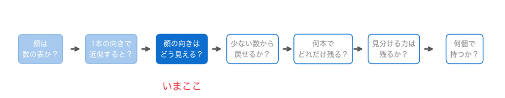

- 2画素では、角度を回して向きを探せた
- 4,096画素では、向きは4,096個の数の並び。回して探せない

## お手本：4,096画素でPCA

3節 ① 4,096画素で●○

```python
pca = PCA(random_state=0).fit(X_tr)
print(pca.components_.shape)
print(np.abs(pca.mean_ - mean_face).max())
```

- `n_components`を書かないと、求められるだけ求める
- `random_state=0`：中で乱数を使う場合も、毎回同じ結果に
- `mean_`：`PCA`が引いた平均

## 向きは300本

3節 ① 4,096画素で●●

```
(300, 4096)
0.0
```

- 1本が4,096個の数。300枚からなので、枚数までしか作れない
- `PCA`の平均は、1節の平均の顔と同じ（差の最大は0）

## 人の番号は渡していない

3節 ② 教師なし学習●○

```python
pca = PCA(random_state=0).fit(X_tr)
```

- `fit`に渡したのは画素の表`X_tr`だけ。`p_tr`は渡していない

## 名前：教師なし学習

3節 ② 教師なし学習●●

- 答えの列を使う解析：教師あり学習
- 答えの列を使わず、データそのものの形を調べる解析：教師なし学習
- 主成分分析は、教師なし学習の1つ

## お手本：向きを顔として描く

3節 ③ 固有顔●○○○○○

```python
show_faces(pca.components_[:5],
           ['第1', '第2', '第3', '第4', '第5'])
```

[output not shown]

- 向きも4,096個の数。`reshape(64, 64)`で画像にできる
- 顔のデータの向きを顔として描いたものを、固有顔と呼ぶ

## 固有顔

3節 ③ 固有顔●●○○○○

## 第1は顔全体の明るさ

3節 ③ 固有顔●●●○○○

## 第2は光の当たり方

3節 ③ 固有顔●●●●○○

## 第3は眼鏡、第5は口元

3節 ③ 固有顔●●●●●○

## いちばん大きい違いは光

3節 ③ 固有顔●●●●●●

- 写真どうしの違いが大きい順に、向きが並ぶ
- いちばん大きい違いは、顔の形ではなく、撮ったときの光の当たり方

## 各向きが受け持つ割合

3節 ④ 寄与率●○○

- 2節：得点の二乗和＋誤差＝ずれの大きさの合計
- ずれの大きさの合計のうち、ある向きの得点が受け持つ割合を、寄与率と呼ぶ

$$\text{第}k\text{主成分の寄与率} = \frac{\text{第}k\text{主成分の得点の二乗和}}{\text{ずれの大きさの合計}}$$

## お手本：寄与率

3節 ④ 寄与率●●○

```python
print(pca.explained_variance_ratio_[:5].round(3))
```

```
[0.23  0.141 0.081 0.049 0.037]
```

- 寄与率は`explained_variance_ratio_`に入る

## 第1主成分で23%

3節 ④ 寄与率●●●

- 第1主成分の寄与率は0.23。ずれの23%を、1本の向きで受け持つ
- 第2主成分は0.141、第3主成分は0.081と、だんだん小さくなる

## PCAの中では何をしている？

3節 ⑤ 特異値分解●○○

- `PCA`の中では、特異値分解（SVD）という計算で向きを求めている
- 特異値分解：ずれの表（行列）を、3つの行列の積に分ける計算
- numpyの`np.linalg.svd`で、同じ向きが出るかを確かめる

## お手本：特異値分解

3節 ⑤ 特異値分解●●○

```python
U, S, Vt = np.linalg.svd(X_tr - mean_face, full_matrices=False)
print(Vt.shape)
print(abs(Vt[0] @ pca.components_[0]).round(3))
print((S ** 2 / (S ** 2).sum())[:3].round(3))
```

- 長さ1の向きどうしの積は、同じ向きなら1（逆向きなら−1）
- `full_matrices=False`：必要な大きさだけを返す

## 同じ向き、同じ寄与率

3節 ⑤ 特異値分解●●●

```
(300, 4096)
1.0
[0.23  0.141 0.081]
```

- `Vt`の行が`PCA`の向き。`S`の二乗の割合が寄与率
- `PCA`の1行は、この行列の計算をまとめたもの

## やってみよう：3節

3節 ⑥ 確かめる●

- 3節のセルを実行し、固有顔と寄与率を確かめる
- 第4主成分の固有顔は、何の違いに見えるかを考える

動画の人は、ここで一時停止。

# 4. 少ない数から顔を戻せるか？

## 得点だけで持つ

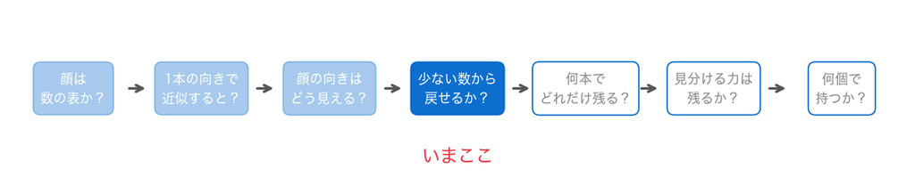

- 最初の何本かの向きの得点だけで持てば、数が少なくなる
- その少ない数から、顔を戻せるか

## 記号で書く：k本の向き

4節 ① 縮める・戻す●○○○

- 2節の1本の向きを、$k$本に広げる
- $k$本の向きを縦に並べた$k$行4,096列の行列：$\mathbf{W}$
- ずれの表（1行が1枚）：$\mathbf{X} - \bar{\mathbf{x}}$

## 縮める・戻す

4節 ① 縮める・戻す●●○○

- 縮める（得点）：$\mathbf{T} = (\mathbf{X} - \bar{\mathbf{x}})\,\mathbf{W}^\top$
- 戻す（再構成）：$\hat{\mathbf{X}} = \mathbf{T}\,\mathbf{W} + \bar{\mathbf{x}}$
- 2節の`t = xc @ W.T`と`t @ W`と同じ形

## 行列の大きさで見る

4節 ① 縮める・戻す●●●○

- テストの100枚を50本で縮めると、1枚が50個の数になる

## 名前：再構成

4節 ① 縮める・戻す●●●●

- 少ない数から元の形に戻すことを、再構成と呼ぶ

## お手本：50本で縮めて戻す

4節 ② 50本で戻す●○○○

```python
W = pca.components_[:50]           # 50本の向き：50行4,096列
T = (X_te - mean_face) @ W.T       # 得点：100行50列
X_hat = T @ W + mean_face          # 再構成：100行4,096列
print(T.shape, X_hat.shape)
show_faces([X_te[0], X_hat[0]], ['写真', '50本で再構成'])
```

- `pca.components_[:50]`：最初の50行（50本の向き）

## 訓練で決めて、テストに使う

4節 ② 50本で戻す●●○○

- 向きと平均は、訓練の300枚で決めたもの
- それを、そのままテストに使う（第3回の「訓練だけで決める」）

## 50個からよく似た顔

4節 ② 50本で戻す●●●○

```
(100, 50) (100, 4096)
```

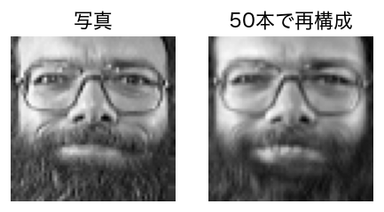

- 1枚50個の数から戻した顔は、元の写真とよく似ている

## まだ見ていない顔でも

4節 ② 50本で戻す●●●●

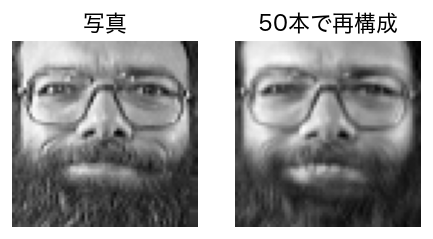

- この顔は、向きを求めた訓練の300枚に入っていない
- まだ見ていない顔でも、50本の向きでおおよそ表せる

## transformも同じ計算

4節 ③ transform●○

```python
print(T[0, :3].round(3))
print(pca.transform(X_te)[0, :3].round(3))
```

```
[-6.944  0.952  3.819]
[-6.944  0.952  3.819]
```

- `transform`は得点を出す部品。中身は、ずれ`@`向きの転置

## fitで覚え、transformで使う

4節 ③ transform●●

- 第7回の`StandardScaler`と同じ形
- `fit`で平均と向きを覚え、`transform`で新しい行を変換する

## TODO③：本数を変えて戻す

4節 ④ 本数を変える●○○○○

```python
# TODO: k = 5, 20, 50, 100 で X_te[0] を再構成し、写真と並べる
# ヒント: faces = [X_te[0]]
#         for k in [5, 20, 50, 100]:
#             W_k = pca.components_[:k]
#             T_k = (X_te[[0]] - mean_face) @ W_k.T
#             faces.append((T_k @ W_k + mean_face)[0])
#         show_faces(faces, ['写真', '5本', '20本', '50本', '100本'])
...
```

- `X_te[[0]]`：テストの1枚目を、1行の表として取り出す

## やってみよう：4節とTODO③

4節 ④ 本数を変える●●○○○

- 4節のお手本を実行する
- TODO③で、5・20・50・100本で戻した顔を並べる

動画の人は、ここで一時停止。

## 答え合わせ：TODO③

4節 ④ 本数を変える●●●○○

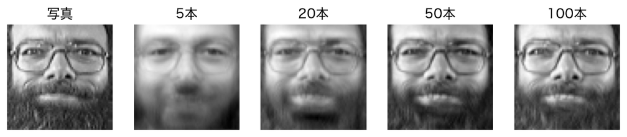

```python
faces = [X_te[0]]
for k in [5, 20, 50, 100]:
    W_k = pca.components_[:k]
    T_k = (X_te[[0]] - mean_face) @ W_k.T
    faces.append((T_k @ W_k + mean_face)[0])
show_faces(faces, ['写真', '5本', '20本', '50本', '100本'])
```

## 増やすほど近づく

4節 ④ 本数を変える●●●●○

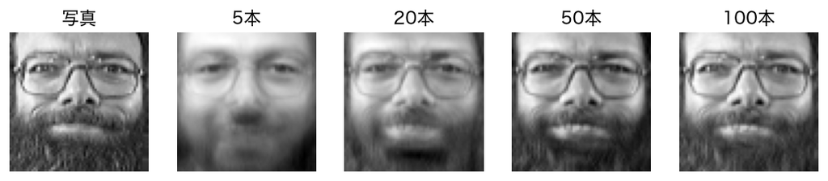

- 5本：眼鏡のあたりが分かるだけの、ぼんやりした顔
- 20本でひげや口元が出て、50本・100本で細かいところまで戻る

## どこまで増やせば十分か？

4節 ④ 本数を変える●●●●●

- 数を増やすほど、元の写真に近づく
- どこまで増やせば十分かを、次の節で数で確かめる

# 5. 何本でどれだけ残るか？

## 2つの数で確かめる

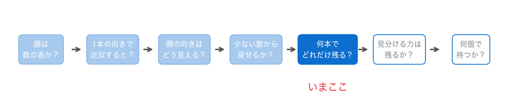

- 訓練の散らばりがどれだけ残るか（累積寄与率）
- テストの顔をどれだけ正確に戻せるか（再構成誤差）

## 名前：累積寄与率

5節 ① 累積寄与率●○○○

- 最初の$k$本の寄与率を足したものを、累積寄与率と呼ぶ
- $k$本の向きで、ずれの大きさの合計の何割を受け持つか

## お手本：累積寄与率

5節 ① 累積寄与率●●○○

```python
cum = pca.explained_variance_ratio_.cumsum()
print(cum[[0, 9, 49, 99]].round(3))
plt.plot(range(1, 301), cum)
plt.xlabel('主成分の本数')
plt.ylabel('累積寄与率')
plt.show()
```

- `cumsum`：前から順に足していった並び
- `cum[9]`は10本目までの和（位置は0から数える）

## 50本で0.88

5節 ① 累積寄与率●●●○

```
[0.23  0.655 0.88  0.945]
```

- 1本0.23、10本0.655、50本0.88、100本0.945

## 初めに急に増える

5節 ① 累積寄与率●●●●

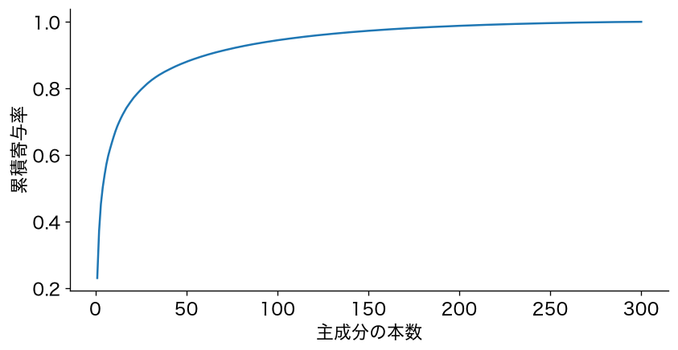

- はじめの数十本で急に増え、あとはゆっくり1に近づく
- 300本すべてなら1（訓練の300枚を誤差0で表せる）

## TODO④：0.9を超える本数

5節 ② 0.9を超える本数●○○○○

```python
# TODO: 累積寄与率が初めて 0.9 以上になる本数を出す
# ヒント: np.argmax(cum >= 0.9) + 1
...
```

- `cum >= 0.9`：True/Falseの並び
- `np.argmax`：いちばん大きい値（Trueは1）が最初に出る位置

## 位置から本数へ

5節 ② 0.9を超える本数●●○○○

- 位置は0から数えるので、本数は`+ 1`する
- `cum[9]`が10本目だったのと同じ

## やってみよう：TODO④

5節 ② 0.9を超える本数●●●○○

- 5節の累積寄与率のお手本を実行する
- TODO④で、累積寄与率が初めて0.9以上になる本数を出す

動画の人は、ここで一時停止。

## 答え合わせ：TODO④

5節 ② 0.9を超える本数●●●●○

```python
print(np.argmax(cum >= 0.9) + 1)
```

```
61
```

## 61個で9割

5節 ② 0.9を超える本数●●●●●

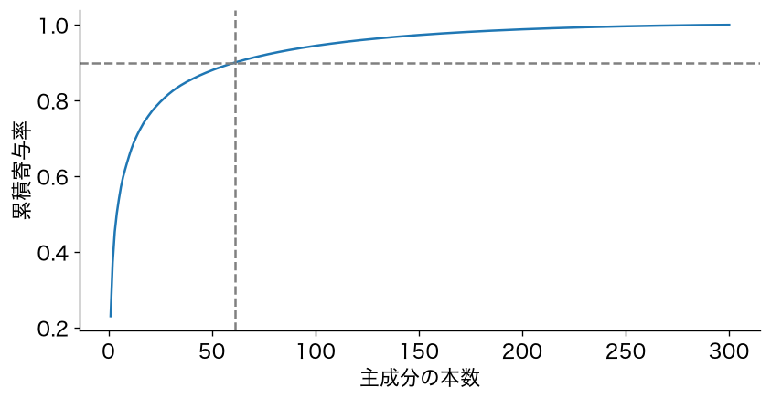

- 4,096個の数のうち61個で、訓練の顔の散らばりの9割を表せる

## まだ見ていない顔は？

5節 ③ 再構成誤差●○○○○○

- 累積寄与率は、向きを求めた訓練の300枚の数
- まだ見ていないテストの顔も、同じように戻せるか

## 名前：再構成誤差

5節 ③ 再構成誤差●●○○○○

- 画素1つあたりの、元と再構成の差の二乗の平均を、再構成誤差と呼ぶ
- 0本は、平均の顔だけで戻したとき

$$\frac{1}{100 \times 4096}\sum_{i}\sum_{\text{画素}} (\mathbf{x}_i - \hat{\mathbf{x}}_i)^2$$

## お手本：再構成誤差

5節 ③ 再構成誤差●●●○○○

```python
ks = [0, 5, 10, 20, 50, 100, 200]
rec_err = []
for k in ks:
    W_k = pca.components_[:k]
    X_hat_k = (X_te - mean_face) @ W_k.T @ W_k + mean_face
    rec_err.append(((X_te - X_hat_k) ** 2).mean())
print(np.round(rec_err, 4))
plt.plot(ks, rec_err, marker='o')
plt.xlabel('主成分の本数')
plt.ylabel('テストの再構成誤差')
plt.show()
```

## テストでも小さくなる

5節 ③ 再構成誤差●●●●○○

```
[0.0202 0.0091 0.0071 0.0053 0.0035 0.0026 0.002 ]
```

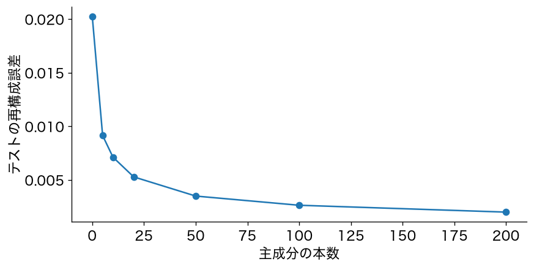

## 50本を超えるとゆるやか

5節 ③ 再構成誤差●●●●●○

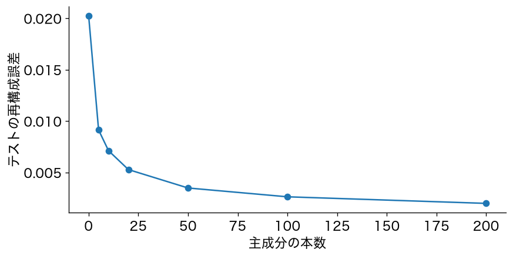

- 0本で0.0202、50本で0.0035、100本で0.0026
- 50本を超えると、減り方はゆるやかになる

## 見た目より、見分けられるか

5節 ③ 再構成誤差●●●●●●

- 50本ほどで、顔の見た目はかなり残る
- けれども、顔認証で大事なのは、誰の顔かを見分けられるか

## やってみよう：5節

5節 ④ 確かめる●

- 5節の再構成誤差のお手本を実行する
- 50本と100本で、誤差がどれだけ違うかを確かめる

動画の人は、ここで一時停止。